# Variable Selection using Best Subset and Stepwise Selection

```r
library(tidyverse)
library(data.table)
library(leaps)
```

# Example 1 using Water dataset on Canvas

We will use the Water.csv dataset provided on canvas. This data contains 43 years of snow precipitation (in inches) measured at six different sites ( variables APMAM, APSAB, APSLAKE, OPBPC, OPRC, OPSLAKE) in the Owens Valley, California. You are interested in predicting water availability using the stream runoff variable in acre-feet (BSAAM variable). Accurate stream runoff predictions will help engineers, planners and policy makers to make effective decisions for water conservation.

Load the dataset

```r
dt <- fread("data/Water.csv")[, !c("Year")]
```

Correlation among variables

```r
cor(dt)
```

```
            APMAM      APSAB    APSLAKE      OPBPC      OPRC    OPSLAKE     BSAAM
APMAM   1.0000000 0.82768637 0.81607595 0.12238567 0.1544155 0.10754212 0.2385695
APSAB   0.8276864 1.00000000 0.90030474 0.03954211 0.1056396 0.02961175 0.1832950
APSLAKE 0.8160760 0.90030474 1.00000000 0.09344773 0.1063836 0.10058669 0.2493409
OPBPC   0.1223857 0.03954211 0.09344773 1.00000000 0.8647073 0.94334741 0.8857478
OPRC    0.1544155 0.10563959 0.10638359 0.86470733 1.0000000 0.91914467 0.9196270
OPSLAKE 0.1075421 0.02961175 0.10058669 0.94334741 0.9191447 1.00000000 0.9384360
BSAAM   0.2385695 0.18329499 0.24934094 0.88574778 0.9196270 0.93843604 1.0000000
```

Reduce the number of digits after the decimal

```r
round(cor(dt), 3)
```

```
        APMAM APSAB APSLAKE OPBPC  OPRC OPSLAKE BSAAM
APMAM   1.000 0.828   0.816 0.122 0.154   0.108 0.239
APSAB   0.828 1.000   0.900 0.040 0.106   0.030 0.183
APSLAKE 0.816 0.900   1.000 0.093 0.106   0.101 0.249
OPBPC   0.122 0.040   0.093 1.000 0.865   0.943 0.886
OPRC    0.154 0.106   0.106 0.865 1.000   0.919 0.920
OPSLAKE 0.108 0.030   0.101 0.943 0.919   1.000 0.938
BSAAM   0.239 0.183   0.249 0.886 0.920   0.938 1.000
```

[output not shown]

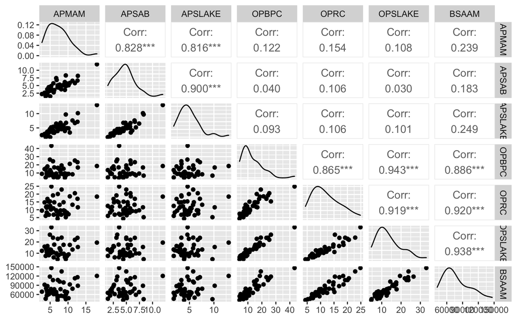

```r
GGally::ggpairs(dt)
```

Linear Model using lm

```r
lm <- lm(BSAAM ~ ., dt)
summary(lm)
```

```
Call:
lm(formula = BSAAM ~ ., data = dt)

Residuals:
   Min     1Q Median     3Q    Max
-12690  -4936  -1424   4173  18542

Coefficients:
            Estimate Std. Error t value Pr(>|t|)
(Intercept) 15944.67    4099.80   3.889 0.000416 ***
APMAM         -12.77     708.89  -0.018 0.985725
APSAB        -664.41    1522.89  -0.436 0.665237
APSLAKE      2270.68    1341.29   1.693 0.099112 .
OPBPC          69.70     461.69   0.151 0.880839
OPRC         1916.45     641.36   2.988 0.005031 **
OPSLAKE      2211.58     752.69   2.938 0.005729 **
---
Signif. codes:  0 ‘***’ 0.001 ‘**’ 0.01 ‘*’ 0.05 ‘.’ 0.1 ‘ ’ 1

Residual standard error: 7557 on 36 degrees of freedom
Multiple R-squared:  0.9248,    Adjusted R-squared:  0.9123
F-statistic: 73.82 on 6 and 36 DF,  p-value: < 2.2e-16
```

Interestingly, OPBPC is not significant despite being highly correlated with the response variable. In short, when we control for the other OP features, OPBPC no longer explains any meaningful variation of the predictor, which is to say that OPBPC adds nothing from a statistical standpoint with OPRC and OPSLAKE already in the model.

## Best Subset Selection

Best subset selection is performed using regsubsets() function which is part of the leaps package. This function identifies the best model that contains a given number of predictors using RSS. The syntax is similar to lm()

```r
best_fit <- regsubsets(BSAAM ~ ., dt, nvmax = 7)
best_summary <- summary(best_fit)
```

Create a best_summary object to examine the AIC, Cp, BIC and Adjusted R-square of the models. The goal is to choose a model with minimum AIC, Cp, BIC but with maximum adjusted R-square.

```r
data.table("BIC" = best_summary$bic,
           "Cp" = best_summary$cp,
           "r2" = best_summary$adjr2)[order(r2 * -1, BIC, Cp)]
```

| BIC | Cp | r2 |
| --- | --- | --- |
| -95.96889 | 1.229691 | 0.9185369 |
| -92.45393 | 3.022811 | 0.9168706 |
| -88.71958 | 5.000325 | 0.9146772 |
| -84.95877 | 7.000000 | 0.9123079 |
| -89.89521 | 8.540279 | 0.9001619 |
| -83.88688 | 18.156640 | 0.8777515 |

In a linear model, AIC and Cp are proportional to each other, so we will only concern ourselves with Cp, which follows the output available in the leaps package. BIC tends to select the models with fewer variables than Cp, so we will compare both. To do so, we can create and analyze two plots side by side.

```r
par(mfrow = c(1,2))
plot(best_summary$cp, xlab = "number of features", ylab = "cp")
plot(best_fit, scale = "Cp")
```

[output not shown]

We can also use the following commands to find the models with lowest bic and highest R-square values.

```r
which.min(best_summary$bic)
```

```
[1] 3
```

```r
which.max(best_summary$adjr2)
```

```
[1] 3
```

```r
best_summary$adjr2
```

```
[1] 0.8777515 0.9001619 0.9185369 0.9168706 0.9146772 0.9123079
```

```r
best_summary$bic
```

```
[1] -83.88688 -89.89521 -95.96889 -92.45393 -88.71958 -84.95877
```

Adjusted R-square barely changes when considering a model with 3 or more variables.

A simple model with three predictors can be considered.

```r
regs <- dewey::regsearch(dt, "BSAAM", colnames(dt[, !c("BSAAM")]), 1, 7,
                         "gaussian", 0, FALSE, FALSE)
```

[output not shown]

[output cut: 88 more lines]

[output not shown]

```r
regs <- regs[str_count(formula, "\\+") == 3,]
regs
```

| formula | aic | rSquare | warn | xIntercept | APMAM | APSAB | APSLAKE | OPBPC | OPRC | OPSLAKE | BSAAM |
| --- | --- | --- | --- | --- | --- | --- | --- | --- | --- | --- | --- |
| BSAAM ~ + APSLAKE + OPRC + OPSLAKE | 892.6603 | 0.92436 | NA | 1.329924e-04 | NA | NA | 0.001475121 | NA | 2.998189e-03 | 4.187492e-06 | NA |
| BSAAM ~ + APSLAKE + OPBPC + OPRC | 904.1156 | 0.90126 | NA | 1.624155e-04 | NA | NA | 0.004468609 | 9.562186e-04 | 6.689769e-07 | NA | NA |
| BSAAM ~ + APSAB + OPRC + OPSLAKE | 895.9340 | 0.91837 | NA | 1.389916e-04 | NA | 0.007385890 | NA | NA | 1.517163e-02 | 1.987800e-06 | NA |
| BSAAM ~ + APMAM + OPRC + OPSLAKE | 897.2498 | 0.91584 | NA | 1.051443e-04 | 0.014322247 | NA | NA | NA | 9.619274e-03 | 4.875536e-06 | NA |
| BSAAM ~ + APSAB + APSLAKE + OPRC | 911.7125 | 0.88218 | NA | 1.244698e-03 | NA | 0.042752075 | 0.003618270 | NA | 4.413682e-19 | NA | NA |
| BSAAM ~ + APSAB + OPBPC + OPRC | 908.9867 | 0.88942 | NA | 7.412225e-05 | NA | 0.053774214 | NA | 9.574235e-04 | 3.457935e-06 | NA | NA |
| BSAAM ~ + APMAM + OPBPC + OPRC | 909.3158 | 0.88857 | NA | 8.279809e-05 | 0.064217079 | NA | NA | 1.505333e-03 | 2.460065e-06 | NA | NA |
| BSAAM ~ + APMAM + APSLAKE + OPRC | 915.6193 | 0.87098 | NA | 3.641097e-03 | 0.436120905 | NA | 0.035406422 | NA | 2.338868e-18 | NA | NA |
| BSAAM ~ + APMAM + APSLAKE + OPSLAKE | 902.3122 | 0.90532 | NA | 3.870024e-05 | 0.685667024 | NA | 0.140729282 | NA | NA | 5.490826e-21 | NA |
| BSAAM ~ + APMAM + APSAB + OPSLAKE | 902.3903 | 0.90515 | NA | 8.516826e-05 | 0.735291766 | 0.147297530 | NA | NA | NA | 4.785271e-21 | NA |

[output cut: 10 more lines]

```r
form <- as.formula("BSAAM ~ + APSLAKE + OPRC + OPSLAKE")
```

## Forward and Backward Selection

regsubsets() can be used to perform forward or backward stepwise selection using the argument method =“forward” or method = “backward”

```r
best_fit <- regsubsets(BSAAM ~ ., dt, nvmax = 7, method = "forward")
best_summary <- summary(best_fit)

data.table("BIC" = best_summary$bic,
           "Cp" = best_summary$cp,
           "r2" = best_summary$adjr2)[order(r2 * -1, BIC, Cp)]
```

| BIC | Cp | r2 |
| --- | --- | --- |
| -95.96889 | 1.229691 | 0.9185369 |
| -92.45393 | 3.022811 | 0.9168706 |
| -88.71958 | 5.000325 | 0.9146772 |
| -84.95877 | 7.000000 | 0.9123079 |
| -89.89521 | 8.540279 | 0.9001619 |
| -83.88688 | 18.156640 | 0.8777515 |

```r
par(mfrow = c(1,2))
plot(best_summary$cp, xlab = "number of features", ylab = "cp")
plot(best_fit, scale = "Cp")
```

[output not shown]

```r
best_fit <- regsubsets(BSAAM ~ ., dt, nvmax = 7, method = "backward")
best_summary <- summary(best_fit)

data.table("BIC" = best_summary$bic,
           "Cp" = best_summary$cp,
           "r2" = best_summary$adjr2)[order(r2 * -1, BIC, Cp)]
```

| BIC | Cp | r2 |
| --- | --- | --- |
| -95.96889 | 1.229691 | 0.9185369 |
| -92.45393 | 3.022811 | 0.9168706 |
| -88.71958 | 5.000325 | 0.9146772 |
| -84.95877 | 7.000000 | 0.9123079 |
| -89.89521 | 8.540279 | 0.9001619 |
| -83.88688 | 18.156640 | 0.8777515 |

```r
par(mfrow = c(1,2))
plot(best_summary$cp, xlab = "number of features", ylab = "cp")
plot(best_fit, scale = "Cp")
```

[output not shown]

We can see that the model results from all the above three methods are the same.

#Example 2: Using Hitters dataset from ISLR2 package

```r
dt <- data.table(ISLR2::Hitters)
head(dt)
```

| AtBat | Hits | HmRun | Runs | RBI | Walks | Years | CAtBat | CHits | CHmRun | CRuns | CRBI | CWalks | League | Division | PutOuts | Assists | Errors | Salary | NewLeague |
| --- | --- | --- | --- | --- | --- | --- | --- | --- | --- | --- | --- | --- | --- | --- | --- | --- | --- | --- | --- |
| 293 | 66 | 1 | 30 | 29 | 14 | 1 | 293 | 66 | 1 | 30 | 29 | 14 | A | E | 446 | 33 | 20 | NA | A |
| 315 | 81 | 7 | 24 | 38 | 39 | 14 | 3449 | 835 | 69 | 321 | 414 | 375 | N | W | 632 | 43 | 10 | 475.0 | N |
| 479 | 130 | 18 | 66 | 72 | 76 | 3 | 1624 | 457 | 63 | 224 | 266 | 263 | A | W | 880 | 82 | 14 | 480.0 | A |
| 496 | 141 | 20 | 65 | 78 | 37 | 11 | 5628 | 1575 | 225 | 828 | 838 | 354 | N | E | 200 | 11 | 3 | 500.0 | N |
| 321 | 87 | 10 | 39 | 42 | 30 | 2 | 396 | 101 | 12 | 48 | 46 | 33 | N | E | 805 | 40 | 4 | 91.5 | N |
| 594 | 169 | 4 | 74 | 51 | 35 | 11 | 4408 | 1133 | 19 | 501 | 336 | 194 | A | W | 282 | 421 | 25 | 750.0 | A |

```r
dim(dt)
```

```
[1] 322  20
```

We are interested in determining the performance factors that affect the salary.

Check for missing values

Remove the 59 players with missing salary information

```r
dt <- dt[rowSums(is.na(dt)) == 0]
```

Best subset selection using regsubsets

```r
best_fit <- regsubsets(Salary ~ ., dt)
best_summary <- summary(best_fit)

data.table("BIC" = best_summary$bic,
           "Cp" = best_summary$cp,
           "r2" = best_summary$adjr2)[order(r2 * -1, BIC, Cp)]
```

| BIC | Cp | r2 |
| --- | --- | --- |
| -147.61525 | 7.400719 | 0.5137083 |
| -145.25594 | 13.128474 | 0.5007849 |
| -147.91690 | 14.023870 | 0.4972001 |
| -144.07143 | 21.613011 | 0.4808971 |
| -141.80892 | 27.856220 | 0.4672734 |
| -135.62693 | 38.693127 | 0.4450753 |
| -128.92622 | 50.723090 | 0.4208024 |
| -90.84637 | 104.281319 | 0.3188503 |

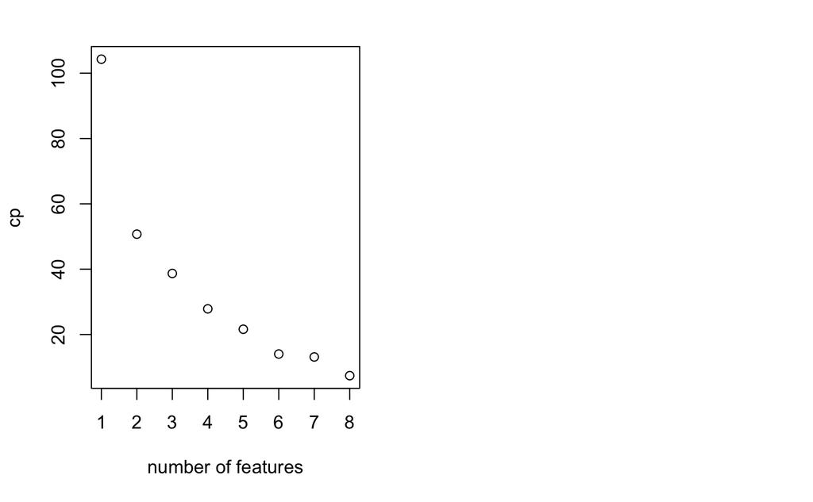

```r
par(mfrow = c(1,2))
plot(best_summary$cp, xlab = "number of features", ylab = "cp")
plot(best_fit, scale = "Cp")
```

By default regsubsets() only reports results up to the best eight-variable model. We can fit as many variables as we want by using the nvmax option as follows:

```r
best_fit <- regsubsets(Salary ~ ., dt, nvmax = 19)
best_summary <- summary(best_fit)

data.table("BIC" = best_summary$bic,
           "Cp" = best_summary$cp,
           "r2" = best_summary$adjr2)[order(r2 * -1, BIC, Cp)]
```

| BIC | Cp | r2 |
| --- | --- | --- |
| -138.86077 | 5.874113 | 0.5225706 |
| -143.21651 | 5.009317 | 0.5222606 |
| -133.87283 | 7.330766 | 0.5217245 |
| -128.77759 | 8.888112 | 0.5206736 |
| -123.64420 | 10.481576 | 0.5195431 |
| -145.44316 | 6.158685 | 0.5180572 |
| -118.21832 | 12.346193 | 0.5178661 |
| -112.81768 | 14.187546 | 0.5162219 |
| -107.35339 | 16.087831 | 0.5144464 |
| -147.61525 | 7.400719 | 0.5137083 |

[output cut: 9 more lines]

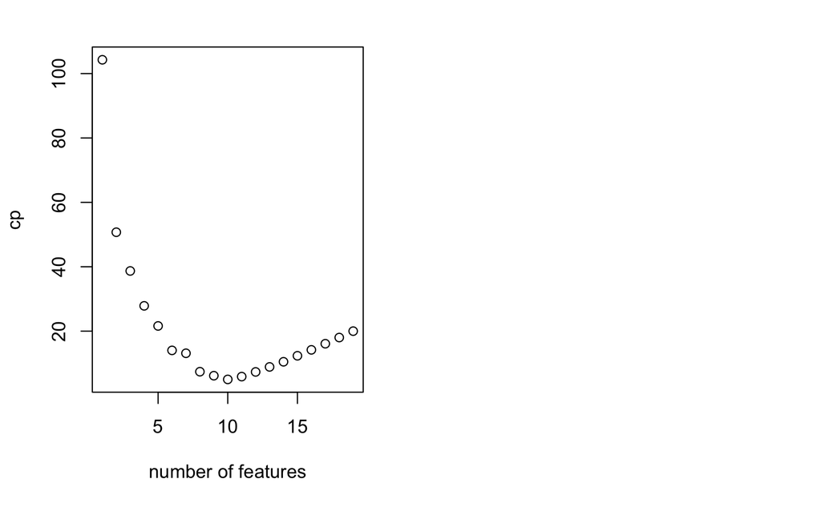

```r
par(mfrow = c(1,2))
plot(best_summary$cp, xlab = "number of features", ylab = "cp")
plot(best_fit, scale = "Cp")
```

Check the r-sq and Cp values

```r
data.table("BIC" = best_summary$bic,
           "Cp" = best_summary$cp,
           "r2" = best_summary$adjr2)[order(r2 * -1, BIC, Cp)]
```

| BIC | Cp | r2 |
| --- | --- | --- |
| -138.86077 | 5.874113 | 0.5225706 |
| -143.21651 | 5.009317 | 0.5222606 |
| -133.87283 | 7.330766 | 0.5217245 |
| -128.77759 | 8.888112 | 0.5206736 |
| -123.64420 | 10.481576 | 0.5195431 |
| -145.44316 | 6.158685 | 0.5180572 |
| -118.21832 | 12.346193 | 0.5178661 |
| -112.81768 | 14.187546 | 0.5162219 |
| -107.35339 | 16.087831 | 0.5144464 |
| -147.61525 | 7.400719 | 0.5137083 |

[output cut: 9 more lines]

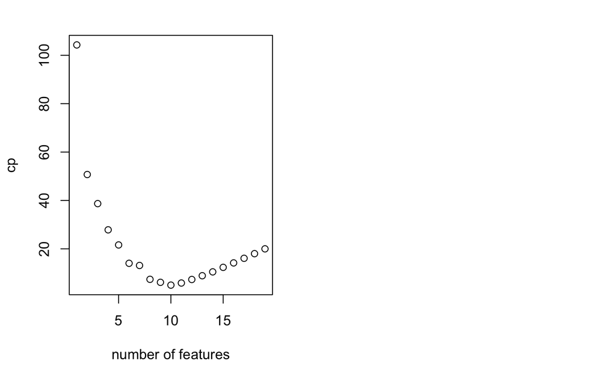

```r
par(mfrow = c(1,2))
plot(best_summary$cp, xlab = "number of features", ylab = "cp")
plot(best_fit, scale = "bic")
```

```r
best_fit <- regsubsets(Salary ~ ., dt, nvmax = 19, method = "forward")
best_summary <- summary(best_fit)

data.table("BIC" = best_summary$bic,
           "Cp" = best_summary$cp,
           "r2" = best_summary$adjr2)[order(r2 * -1, BIC, Cp)]
```

| BIC | Cp | r2 |
| --- | --- | --- |
| -138.86077 | 5.874113 | 0.5225706 |
| -143.21651 | 5.009317 | 0.5222606 |
| -133.87283 | 7.330766 | 0.5217245 |
| -128.77759 | 8.888112 | 0.5206736 |
| -123.64420 | 10.481576 | 0.5195431 |
| -145.44316 | 6.158685 | 0.5180572 |
| -118.21832 | 12.346193 | 0.5178661 |
| -112.81768 | 14.187546 | 0.5162219 |
| -107.35339 | 16.087831 | 0.5144464 |
| -147.38199 | 7.624674 | 0.5132768 |

[output cut: 9 more lines]

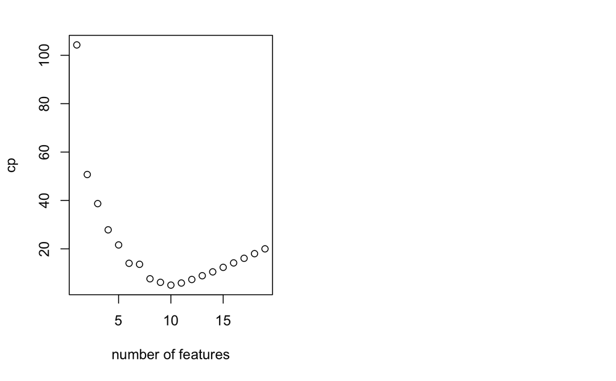

```r
par(mfrow = c(1,2))
plot(best_summary$cp, xlab = "number of features", ylab = "cp")
plot(best_fit, scale = "Cp")
```

```r
best_fit <- regsubsets(Salary ~ ., dt, nvmax = 19, method = "backward")
best_summary <- summary(best_fit)

data.table("BIC" = best_summary$bic,
           "Cp" = best_summary$cp,
           "r2" = best_summary$adjr2)[order(r2 * -1, BIC, Cp)]
```

| BIC | Cp | r2 |
| --- | --- | --- |
| -138.86077 | 5.874113 | 0.5225706 |
| -143.21651 | 5.009317 | 0.5222606 |
| -133.87283 | 7.330766 | 0.5217245 |
| -128.77759 | 8.888112 | 0.5206736 |
| -123.64420 | 10.481576 | 0.5195431 |
| -145.44316 | 6.158685 | 0.5180572 |
| -118.21832 | 12.346193 | 0.5178661 |
| -112.81768 | 14.187546 | 0.5162219 |
| -107.35339 | 16.087831 | 0.5144464 |
| -147.38199 | 7.624674 | 0.5132768 |

[output cut: 9 more lines]

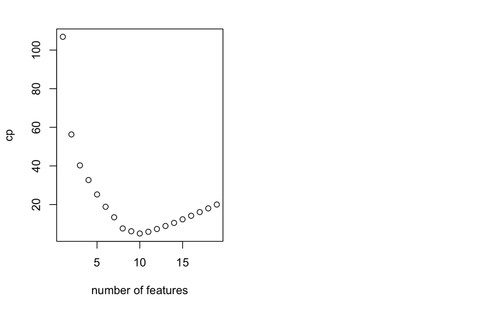

```r
par(mfrow = c(1,2))
plot(best_summary$cp, xlab = "number of features", ylab = "cp")
plot(best_fit, scale = "Cp")
```

```r
regs <- dewey::regsearch(dt, "Salary", colnames(dt[, !c("Salary")]), 1, 19,
                         "gaussian", 0, FALSE, TRUE)
```

The best one-variable through six-variable models are identical for best subset and forward selection. However, the best seven-variable models identified by best subset, forward and backward selection are different.